# Forecasting ATM Withdrawal Residents Water Pipe

## Now, we are done with house keeping of data, and in a position to convert into time series.

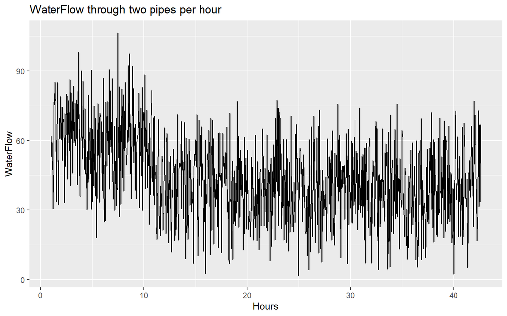

```r
water_data_ts <-ts(water_data$WaterFlow, frequency = 24)
autoplot(water_data_ts) + ggtitle("WaterFlow through two pipes per hour") + xlab("Hours") + ylab("WaterFlow")
```

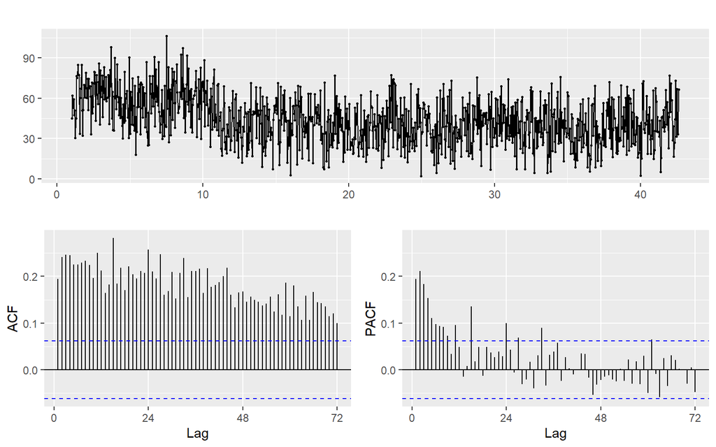

```r
ggtsdisplay(water_data_ts)
```

Observation: The data is not stationary. So, we’ll perform BoxCox with one lag of differencing.

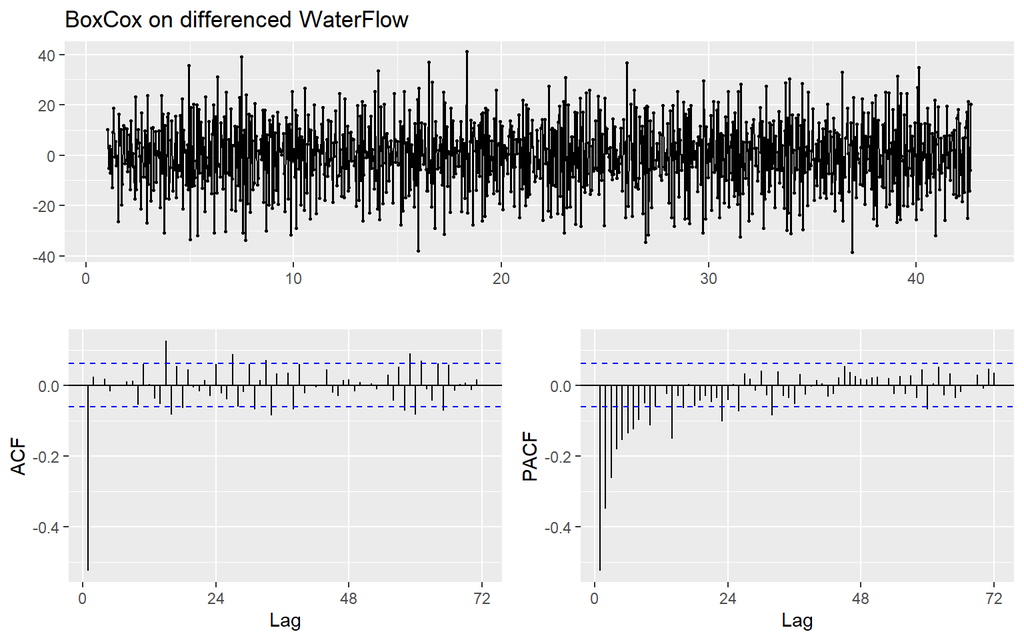

```r
water_data_ts_box <- BoxCox(water_data_ts, BoxCox.lambda(water_data_ts))

ggtsdisplay(diff(water_data_ts_box), main = "BoxCox on differenced WaterFlow")
```

Observations:  
- The time series is stationary.  
- ACF has a big spike.  
- No seasonality.

Now, I’ll determine the ARIM coordinates, with auto.arima().

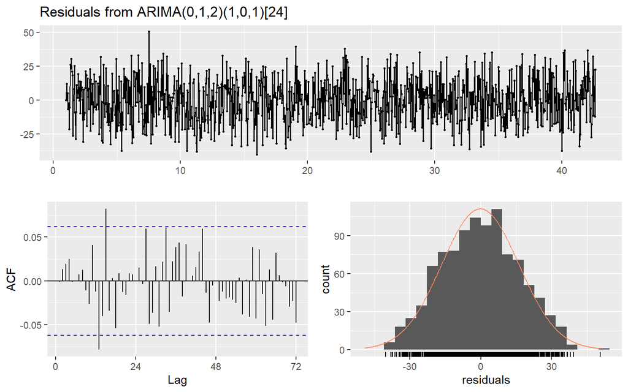

```
##
##  Ljung-Box test
##
## data:  Residuals from ARIMA(0,1,2)(1,0,1)[24]
## Q* = 53.956, df = 44, p-value = 0.1445
##
## Model df: 4.   Total lags used: 48
```

```r
water_data_ts_autoarima_fit <- auto.arima(water_data_ts)
checkresiduals(water_data_ts_autoarima_fit)
```

## The forecast.

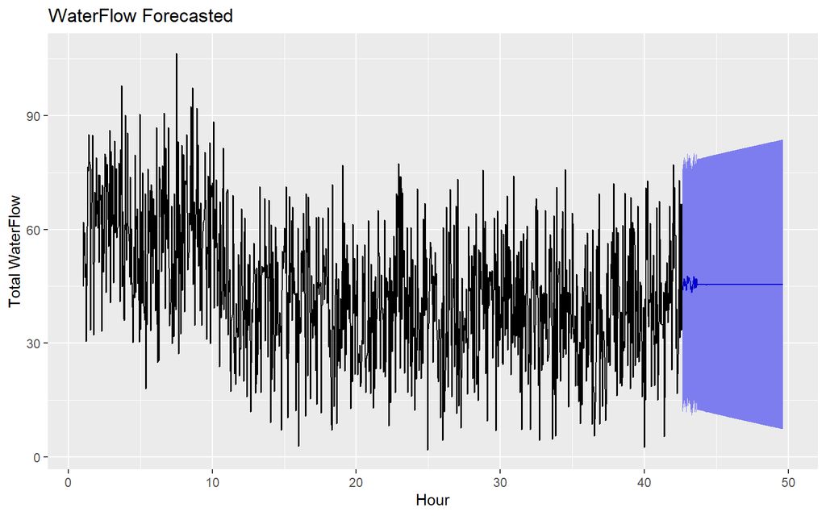

```r
water_data_ts_autoarima_forecast <- forecast(water_data_ts_autoarima_fit, 24 * 7, level = 95)

autoplot(water_data_ts_autoarima_forecast) + ggtitle("WaterFlow Forecasted") + xlab("Hour") + ylab("Total WaterFlow")
```

# Consilodation of forecasts into output spread sheet.

Writing WaterFlow forecasts in Excel.

```r
water_data_ts_forecast_df <- data.frame(DateTime = max(water_data$DateTime) + hours(1:168), WaterFlow = water_data_ts_autoarima_forecast$mean)
write.xlsx(water_data_ts_forecast_df, "Waterflow_Pipe-Forecasts.xlsx")
```

Marker: 624-07_p